# MACT 4233 - Assignment 2

Question 2. Consider any bivariate normal random vector X = (X1, X2)^T , that is X ∼ N2(μ, Σ), other than the standard bivariate normal random vector. For each of the following 4 cases, specify μ and Σ, then sketch the ellipse resulting from cutting the density function with a plane parallel to the space spanned by the axes.

```r
if(!require("MASS")) install.packages("MASS")
if(!require("ellipse")) install.packages("ellipse")
library(MASS)
library(ellipse)
```

1. The two variables are independent with equal variances.

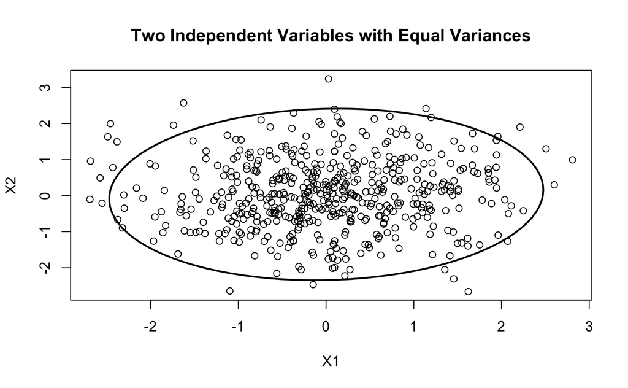

```r
# Define the mean vector
mu = c(0,0)

# Define the covariance matrix (equal variances)
Simga = matrix(c(1, 0,
                 0, 1), nrow = 2)

# Generate a bivariate normal sample
set.seed(123)
my_x = mvrnorm(n = 500, mu = mu, Sigma = Simga)

# Compute the mean and covariance of the sample
sample_mean = colMeans(my_x)

sample_cov = var(my_x)

plot(my_x, main = "Two Independent Variables with Equal Variances", xlab = "X1", ylab = "X2")

# Add an ellipse to the plot
ellipse_data = ellipse(sample_cov, centre = sample_mean, level = 0.95)
lines(ellipse_data, lwd = 2)
```

2. The two variables are independent with unequal variances.

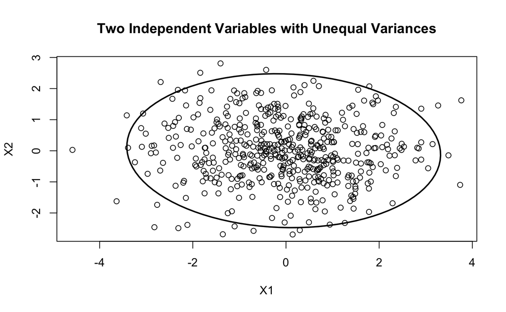

```r
# Define the mean vector
mu = c(0,0)

# Define the covariance matrix (unequal variances)
Simga = matrix(c(2, 0,
                 0, 1), nrow = 2)

# Generate a bivariate normal sample
set.seed(123)
my_x = mvrnorm(n = 500, mu = mu, Sigma = Simga)

# Compute the mean and covariance of the sample
sample_mean = colMeans(my_x)
sample_cov = var(my_x)

plot(my_x, main = "Two Independent Variables with Unequal Variances", xlab = "X1", ylab = "X2")

# Add an ellipse to the plot
ellipse_data = ellipse(sample_cov, centre = sample_mean, level = 0.95)
lines(ellipse_data, lwd = 2)
```

3. The two variables are positively correlated with equal variances.

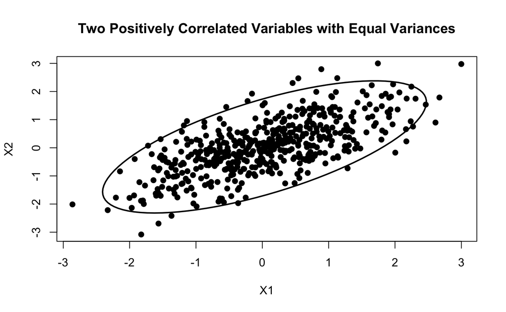

```r
# Define the mean vector
mu = c(0, 0)

# Define the covariance matrix (positively correlated with equal variances)
Sigma = matrix(c(1, 0.7,
                 0.7, 1), nrow = 2)

# Generate a bivariate normal sample
set.seed(123)
my_x = mvrnorm(n = 500, mu = mu, Sigma = Sigma)

# Compute the mean and covariance of the sample
sample_mean = colMeans(my_x)
sample_cov = var(my_x)

plot(my_x, main = "Two Positively Correlated Variables with Equal Variances", xlab = "X1", ylab = "X2", pch = 19)

# Add the ellipse to the plot
ellipse_data = ellipse(sample_cov, centre = sample_mean, level = 0.95)
lines(ellipse_data, lwd = 2)
```

4. The two variables are negatively correlated with unequal variances.

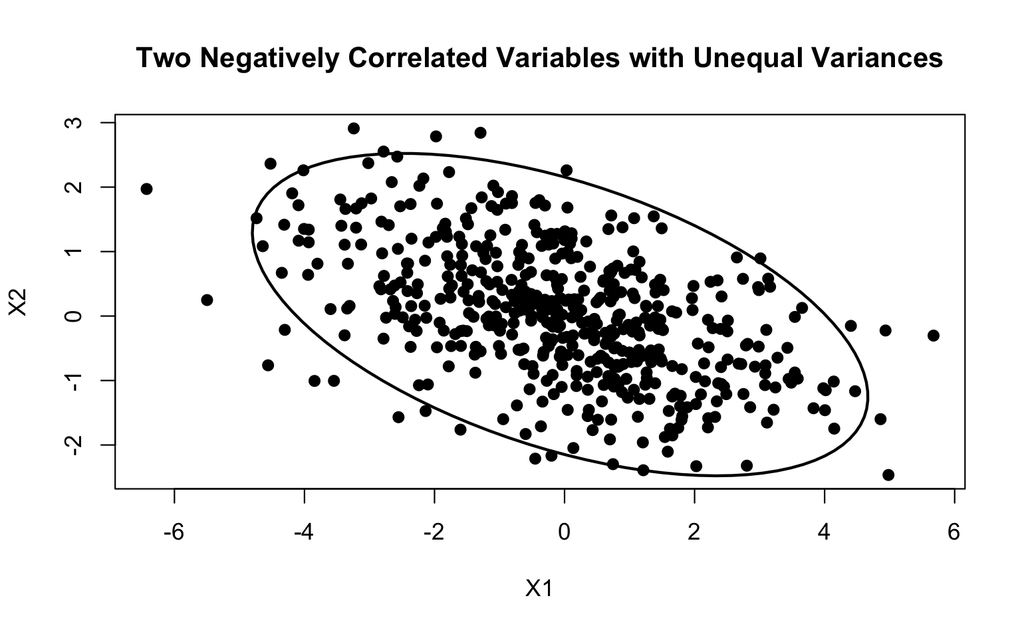

```r
# Define the mean vector
mu = c(0, 0)

# Define the covariance matrix (negatively correlated with unequal variances)
Sigma = matrix(c(4, -1,
                 -1, 1), nrow = 2)

# Generate a bivariate normal sample
set.seed(123)
my_x = mvrnorm(n = 500, mu = mu, Sigma = Sigma)

# Compute the mean and covariance of the sample
sample_mean = colMeans(my_x)
sample_cov = var(my_x)

plot(my_x, main = "Two Negatively Correlated Variables with Unequal Variances", xlab = "X1", ylab = "X2", pch = 19)

# Add the ellipse to the plot
ellipse_data = ellipse(sample_cov, centre = sample_mean, level = 0.95)
lines(ellipse_data, lwd = 2)
```

Question 3. For each of the 4 cases in Question 2, compute the length and the direction of each axes

Case (a): Independent Variables with Equal Variances

```r
# Define the covariance matrix
Sigma = matrix(c(1, 0,
                  0, 1), nrow = 2)

# Eigen decomposition
eig = eigen(Sigma)

# Length of axes
axis_lengths = 2 * sqrt(eig$values)
cat("Lengths of axes:", axis_lengths, "\n")
```

```
Lengths of axes: 2 2
```

```r
# Direction of axes (eigen-vectors)
cat("Directions of axes:\n")
```

```
Directions of axes:
```

```r
print(eig$vectors)
```

```
     [,1] [,2]
[1,]    0   -1
[2,]    1    0
```

Case (b): Independent Variables with Unequal Variances

```r
# Redfine the covariance matrix from Question 2b
Sigma = matrix(c(2, 0,
                  0, 1), nrow = 2)

# Eigen decomposition
eig = eigen(Sigma)

# Length of axes
axis_lengths = 2 * sqrt(eig$values)
cat("Lengths of axes:", axis_lengths, "\n")
```

```
Lengths of axes: 2.828427 2
```

```r
# Direction of axes (eigenvectors)
cat("Directions of axes:\n")
```

```
Directions of axes:
```

```r
print(eig$vectors)
```

```
     [,1] [,2]
[1,]   -1    0
[2,]    0   -1
```

Case (c): Positively Correlated Variables with Equal Variances

```r
# Redefine the covariance matrix from Question 2c
Sigma = matrix(c(1, 0.7,
                  0.7, 1), nrow = 2)

# Eigen decomposition
eig = eigen(Sigma)

# Length of axes
axis_lengths = 2 * sqrt(eig$values)
cat("Lengths of axes:", axis_lengths, "\n")
```

```
Lengths of axes: 2.607681 1.095445
```

```r
# Direction of axes (eigen-vectors)
cat("Directions of axes:\n")
```

```
Directions of axes:
```

```r
print(eig$vectors)
```

```
          [,1]       [,2]
[1,] 0.7071068 -0.7071068
[2,] 0.7071068  0.7071068
```

Case (d): Negatively Correlated Variables with Unequal Variances

```r
# Redfine the covariance matrix from Question 2d
Sigma = matrix(c(4, -1,
                 -1, 1), nrow = 2)

# Eigen decomposition
eig = eigen(Sigma)

# Length of axes
axis_lengths = 2 * sqrt(eig$values)
cat("Lengths of axes:", axis_lengths, "\n")
```

```
Lengths of axes: 4.148627 1.669999
```

```r
# Direction of axes (eigen-vectors)
cat("Directions of axes:\n")
```

```
Directions of axes:
```

```r
print(eig$vectors)
```

```
           [,1]       [,2]
[1,] -0.9570920 -0.2897841
[2,]  0.2897841 -0.9570920
```